# **Report LabRI Tool (v5.5.3)**

### 3.3. Estimated Reference Interval

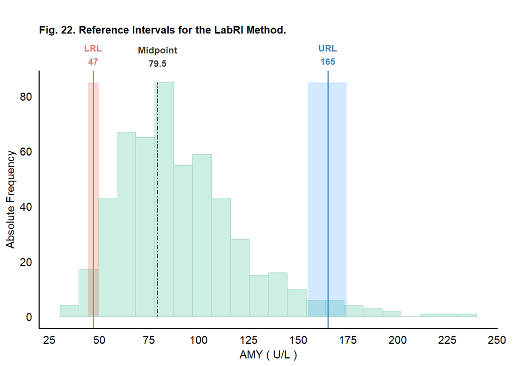

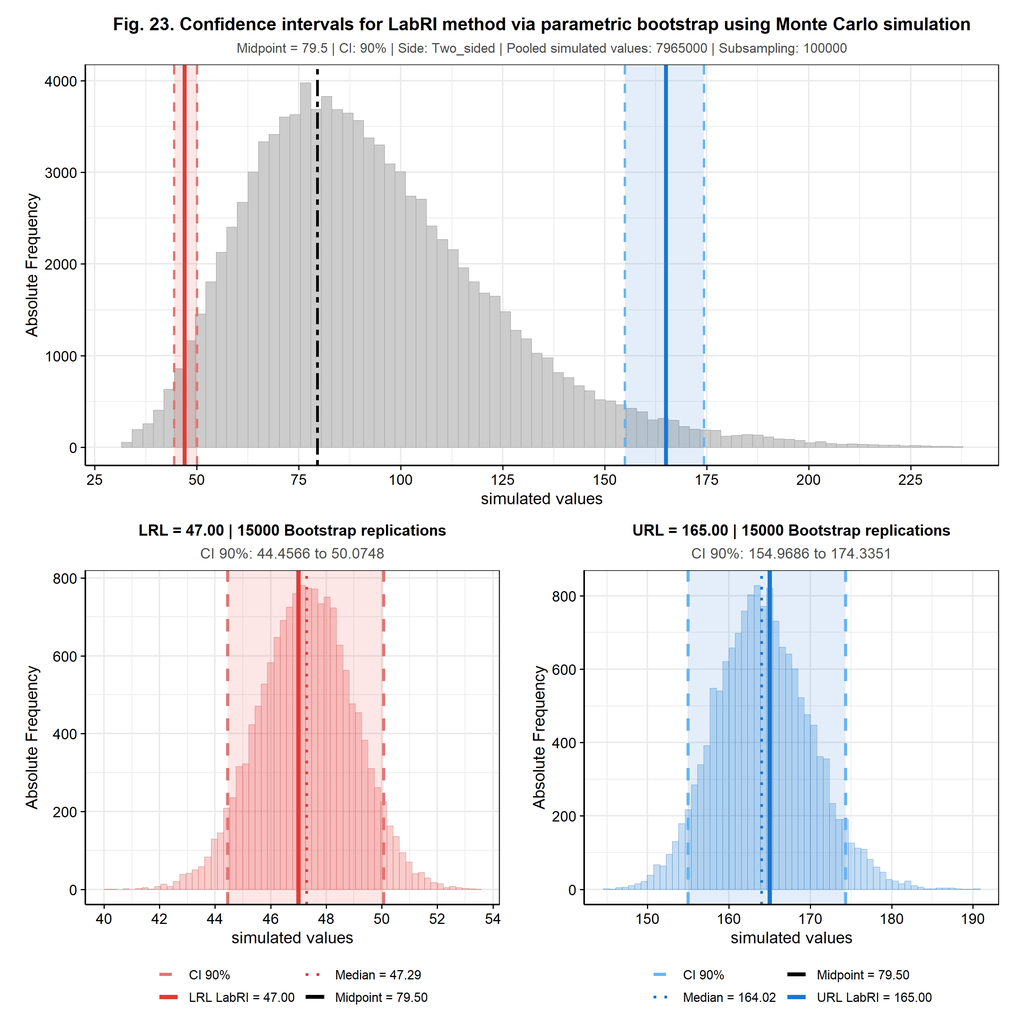

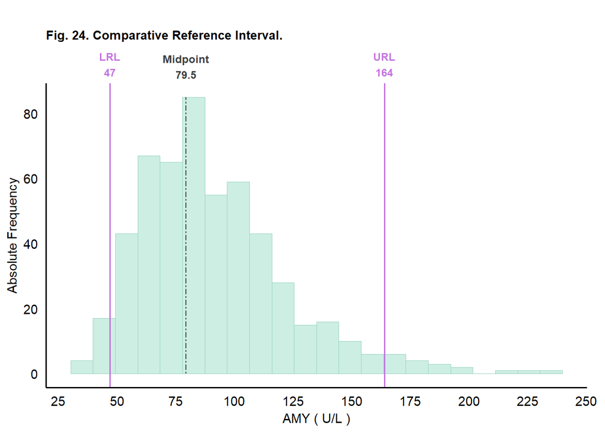

**Table 16.** Reference Interval estimated by the LabRI Method of AMY ( U/L ) , Age: 18 to 65 years , Sex: Male and Female (n = 531 ; Midpoint = 79.5 ).

| LabRI Method | 95% RI, Two sided | 90 % CI of the LRL | 90 % CI of the URL |
| --- | --- | --- | --- |
| Results | 47 to 165 | 44.5 to 50.1 | 155 to 174.3 |

Footnote  
**RI**, reference interval. **CI**, confidence interval. **LRL**, lower reference limit. **URL**, upper reference limit. **SD**, standard deviation **Main references to develop the LabRI method (Estimation Module):** [[1]](https://doi.org/10.32614/CRAN.package.reflimR), [[12]](https://doi.org/10.1515/CCLM.2010.273), [[13]](https://doi.org/10.1515/CCLM.2007.249), [[14]](https://doi.org/10.32614/CRAN.package.mixR), [[15]](https://doi.org/10.18637/jss.v097.i09), [[16]](https://doi.org/10.32614/CRAN.package.moments), [[17]](https://doi.org/10.32614/CRAN.package.mclust), [[18]](https://doi.org/10.32614/CRAN.package.modeest), [[19]](https://doi.org/10.1515/labmed-2024-0118), [[20]](https://doi.org/10.3109/00365519509088450), [[21]](https://doi.org/10.1016/j.jmsacl.2022.02.004), [[22]](https://doi.org/10.32614/CRAN.package.refineR), [[23]](https://doi.org/10.1515/labmed-2020-0157), [[24]](https://www.ncbi.nlm.nih.gov/pmc/articles/PMC6544248/#b44-cbr-40-99), [25], [[26]](https://doi.org/10.1515/CCLM.2009.290) **Comparative Reference Interval:** 47 to 164 U/L **Source of the Comparative Reference Interval:** Information available in the article published by Omuse et al., cited as: G. Omuse, K. Ichihara, D. Maina, M. Hoffman, E. Kagotho, A. Kanyua, J. Mwangi, C. Wambua, A. Amayo, P. Ojwang, Z. Premji, R. Erasmus. Determination of reference intervals for common chemistry and immunoassay tests for Kenyan adults based on an internationally harmonized protocol and up-to-date statistical methods. PLoS ONE, 15 (2020): e0235234. https://doi.org/10.1371/journal.pone.0235234

## 4. Verification Module

- It is important for laboratories to verify their RIs before applying them for routine clinical care. This requirement applies to reference intervals derived using the indirect approach.

About the **verification module** of the LabRI method:

- A three-level analysis is performed, and after this analysis, the tool concludes whether the compared reference limits are equivalent or not. The first stage is called “**First-Level Analysis ~ Statistical Uncertainty**”. The second stage is called “**Second-Level Analysis ~ Distance Criterion Based on Equivalence Testing**”. The third stage is called “**Third-Level Analysis ~ Concordance Evaluation**”.
- The **first-level analysis** evaluates the magnitude of the statistical uncertainty associated with the reference limits. If this statistical uncertainty is acceptable, the **second-level analysis** is performed, which compares the reference limit estimated by the LabRI method with the comparative reference limit. Therefore, in the second-level analysis, it is assessed, through equivalence testing, whether the differences between the compared reference limits are practically significant.
- The **third-level analysis** is only applied if the interpretation of the equivalence test is “**Possible Equivalence**” or “**Probable Equivalence**”, as in these cases, the confidence interval of the equivalence test incorporates one of the equivalence limits. In these cases, three approaches are used in the third-level analysis: Fleiss’ Kappa test, Lin’s Concordance Correlation Coefficient, and Flagging Rates.

### 4.1. First-level analysis

The number of values (results or individuals selected) directly affects the accuracy of the calculation of reference limits. The calculation of the Confidence Interval (CI) for each reference limit allows for validation of the number of selected individuals (sample size). It is generally accepted that the 90% CI for each reference limit should be less than 0.2 times the width of the 95% Reference Interval (RI) in question.

**4.1.1. Interpretation of the first-level analysis**

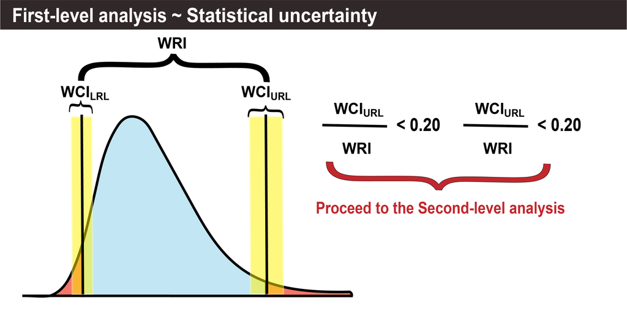

**4.1.2. Results obtained from the first-level analysis**

**Table 17.** Evaluating the magnitude of the statistical uncertainty associated with the reference limits.

| Statistical Parameters | Lower Limit of RI | Upper Limit of RI |
| --- | --- | --- |
| WCI | 50.1 - 44.5 = 5.6 | 174.3 - 155 = 19.3 |
| WRI | 165 - 47 = 118 | 165 - 47 = 118 |
| WCI/WRI ratio | 5.6 / 118 = 0.047 | 19.3 / 118 = 0.164 |
| WCI/WRI ratio | 0.047 | 0.164 |
| WCI/WRI limit | 0.2 | 0.2 |

Footnote  
**WCI**, Width of the Confidence Interval; **WRI**, Width of the 95% Reference Interval. **References:** [[27]](https://doi.org/10.1515/cclm-2016-0793), [[28]](https://doi.org/10.1111/vcp.12065), [[29]](https://doi.org/10.1515/labmed-2020-0131),[[30]](https://doi.org/10.1016/j.clinbiochem.2020.03.012), [[31]](https://doi.org/10.1186/s12874-022-01751-1)

**4.1.3. Conclusion of the first-level analysis**

**Table 18.** First-level analysis conclusion.

[output not shown]

Footnote  
**References:** [[27]](https://doi.org/10.1515/cclm-2016-0793), [[28]](https://doi.org/10.1111/vcp.12065), [[29]](https://doi.org/10.1515/labmed-2020-0131)

### 4.2. Second-level analysis

**4.2.1. Permissible difference for the reference limit (pD<sub>RR</sub>), based on the “Reporting range” (RR) criterion**

- When the RI is narrow, both ratios can be inflated. To address these situations, we have established a pragmatic criterion where the analytical bias reference limits (**D<sub>RL</sub>**) must be equal to or greater than 3 times the **“Reporting range (RR)”** to validate whether the differences between the reference limits are practically relevant (clinically significant).
- The **RR** represents the smallest difference between two reported results, that is, the minimum increment in reported analyte concentrations. In laboratory medicine, this incremental value generally ranges between 0.01 and 10. If the number of digits below the decimal point in reporting test results is 2, 1, or 0, RR is 0.01, 0.1, or 1, respectively.

**Table 19.** Assessing the difference between the upper reference limits (URL) using the RU based criteria.

| Statistical parameters | Results of bias between URL |
| --- | --- |
| \|D<sub>RL</sub>\| | 1 |
| pD<sub>RR</sub> = 3 x RR | 3 x 0.1 = 0.3 |
| Conclusion | The difference between the upper reference limits is discernible from a practical standpoint. |

Footnote  
**D<sub>RL</sub>**, absolute difference (modulus) between the reference limits. **pD<sub>RR</sub>**, value for the permissible difference for the reference limit, based on the Reporting range (RR). **RR**, represents the ‘reporting range’, defined as the incremental value selected to capture changes in analyte concentration, designed to reflect background noise caused by analytical imprecision and biological variation, capturing only significant changes when a true alteration is likely to occur. For example, if the number of digits below the decimal point in reporting test results is 2, 1, or 0, then the RR is 0.01, 0.1, or 1, respectively. **References:** [[32]](https://doi.org/10.1371/journal.pone.0235234), [[33]](https://doi.org/10.1016/j.cca.2006.06.008), [[34]](https://doi.org/10.1373/clinchem.2005.063107), [[35]](https://doi.org/10.1258/0004563041731583), [[36]](https://doi.org/10.1016/j.cca.2009.11.006)

**Table 20.** Assessing the difference between the lower reference limits (LRL) using the RU based criteria.

| Statistical parameters | Results of bias between LRL |
| --- | --- |
| \|D<sub>RL</sub>\| | 0 |
| pD<sub>RR</sub> = 3 x RR | 3 x 0.1 = 0.3 |
| Conclusion | The difference between the lower reference limits is not discernible from a practical standpoint. |

Footnote  
**D<sub>RL</sub>**, absolute difference (modulus) between the reference limits. **pD<sub>RR</sub>**, value for the permissible difference for the reference limit, based on the Reporting range (RR). **RR**, represents the ‘reporting range’, defined as the incremental value selected to capture changes in analyte concentration, designed to reflect background noise caused by analytical imprecision and biological variation, capturing only significant changes when a true alteration is likely to occur. For example, if the number of digits below the decimal point in reporting test results is 2, 1, or 0, then the RR is 0.01, 0.1, or 1, respectively. **References:** [[32]](https://doi.org/10.1371/journal.pone.0235234), [[33]](https://doi.org/10.1016/j.cca.2006.06.008), [[34]](https://doi.org/10.1373/clinchem.2005.063107), [[35]](https://doi.org/10.1258/0004563041731583), [[36]](https://doi.org/10.1016/j.cca.2009.11.006)

**4.2.2. Defining the permissible difference for the reference limit (pD<sub>RL,CV<sub>E</sub></sub>), based on Haeckel’s approach of estimating the empirical coefficient of variation (CV<sub>E</sub>) from the reference interval**

The absolute difference ${ (pD_{LRL} = |LRL_{LabRI} - LRL_{Comp}|)}$ between the two lower reference limits ${(LRL_{LabRI} ; LRL_{Comp})}$ compared should not exceed a permissible difference (${ pD_{LRL}}$) **(eq.3)**. Similarly, the absolute difference ${ (pD_{URL} = |URL_{LabRI} - URL_{Comp}|)}$ between the two upper reference limits (${URL_{LabRI}; URL_{Comp}}$) compared should not exceed a permissible difference (${ pD_{URL}}$) **(eq.4)**.

$$\large{pD_{LRL} \leq 1.645 \times
pS_{A,LRL}}\ \ \ \ \ \ \ \ \ {(eq.3)}$$
$$\large{pD_{URL} \leq 1.645 \times pS_{A,URL}}\ \
\ \ \ \ \ \ \ {(eq.4)}$$

where, **$EI_{LRL}$**, Equivalence Interval (EI) of the Lower Reference Limit (LRL). **$EI_{URL}$**, Equivalence Interval (EI) of the Upper Reference Limit (URL). **$pS_{a,LRL}$**, analytical standard deviation permitted (or clinically irrelevant uncertainty) at the Lower Limit (LRL). **$pS_{a,URL}$**, analytical standard deviation permitted (or clinically irrelevant uncertainty) at the Upper Limit (URL). **Factor 1.645**, the coverage factor used to calculate a one-tailed 95% confidence interval.

**Table 21.** Permissible difference for the reference limit (**pD<sub>RL</sub>**) based on the approach proposed by Haeckel et al., integrating state-of-the-art models with those based on biological variation.

| Method | CV<sub>E</sub> | pCV<sub>A</sub> | Med<sub>ln</sub> | pS<sub>A,Med</sub> | Slope | Intercept | pS<sub>A,LRL</sub> | pS<sub>A,URL</sub> | pD<sub>LRL</sub> | pD<sub>LRL,CV<sub>E</sub></sub> | pD<sub>URL</sub> | pD<sub>URL,CV<sub>E</sub></sub> |
| --- | --- | --- | --- | --- | --- | --- | --- | --- | --- | --- | --- | --- |
| RI<sub>LabRI</sub> | 0.3 | 0.1 | 88.1 | 5 | 0 | 1 | 3.2 | 8.5 | 5.2 | 5.2 | 14.1 | 13.9 |
| RI<sub>Comp</sub> | 0.3 | 0.1 | 87.8 | 5 | 0 | 1 | 3.1 | 8.5 | 5.2 |  | 13.9 |  |

Footnote  
**RI<sub>LabRI</sub>**, reference interval estimated by the LabRI method. **RI<sub>Comp</sub>**, comparative reference interval. **CV<sub>E</sub>**, empirical biological variation coefficient derived from the logarithmic scale, based on the lower reference limit (LRL) and upper reference limit (URL), then converted to the linear scale. If the LRL is not known, it will be set at 15% of the URL for the CV<sub>E</sub> calculation. **pCV<sub>A</sub>**, the permissible CV<sub>A</sub> at the median on the linear scale is obtained from CV<sub>E</sub>. **Med<sub>ln</sub>**, median calculated on the logarithmic scale, as the average of ln(LRI) and ln(LRS), and then converted to the linear scale. **pS<sub>A,Med</sub>**, permissible analytical standard deviation at the median of the reference interval. **Slope**, calculated based on the pS<sub>A,Med</sub> and at the median of the reference interval. **Intercept**, related to the detection limit; because it is usually unknown for human-material matrices, 20% of pS<sub>A,Med</sub> is applied empirically here as a substitute. **pS<sub>A,LRL</sub>**, permissible analytical standard deviation at the LRL. **pS<sub>A,URL</sub>**, permissible analytical standard deviation at the URL. **pD<sub>LRL</sub>**, permissible difference for the lower reference limit. **pD<sub>LRL,CV<sub>E</sub></sub>**, permissible difference for the LRL based on Haeckel’s approach estimating the empirical coefficient of variation CV<sub>E</sub> from the reference interval. **pD<sub>URL</sub>**, permissible difference for the URL. **pD<sub>URL,CV<sub>E</sub></sub>**, permissible difference for the URL based on Haeckel’s approach estimating CV<sub>E</sub> from the reference interval. **References:** [[37]](https://doi.org/10.1515/labmed-2016-0002), [[38]](https://doi.org/10.1515/cclm-2014-0874), [[39]](https://doi.org/10.1515/cclm-2022-1061), [[40]](https://doi.org/10.1515/labmed-2016-0006), [[41]](https://doi.org/10.11613/BM.2017.001), [[42]](https://doi.org/10.1111/ijlh.12898), [[43]](https://doi.org/10.1186/s13063-018-2925-8), [[44]](https://doi.org/10.1046/j.1525-1497.2002.11111.x), [[45]](https://doi.org/10.1002/eng2.12197), [[46]](https://doi.org/10.1016/j.fct.2017.09.044), [[47]](https://doi.org/10.1007/s10055-023-00765-4), [[48]](https://doi.org/10.3343/alm.2020.40.3.201), [[49]](https://doi.org/10.1016/j.tree.2021.10.009), [[50]](https://doi.org/10.11613/BM.2021.010502), [[51]](https://doi.org/10.1080/00031305.2019.1583913), [[52]](https://doi.org/10.1080/00031305.2016.1154108), [[53]](https://doi.org/10.1080/00031305.2018.1564697), [[54]](https://doi.org/10.1515/cclm-2014-1201), [[55]](https://doi.org/10.1007/s10654-011-9563-8), [[56]](https://doi.org/10.1007/s10654-016-0149-3), [[57]](https://doi.org/10.1093/clinchem/48.11.1987), [[58]](https://doi.org/10.1515/labmed-2020-0149), [[59]](https://doi.org/10.1093/clinchem/48.2.338), [[60]](https://doi.org/10.1515/labmed-2016-0036), [[61]](https://doi.org/10.1515/labmed-2017-0041)

**4.2.3. Permissible difference for the reference limit (pD<sub>RL</sub>) selected as the greater value between pD<sub>RR</sub> and pD<sub>RL,CV<sub>E</sub></sub>**

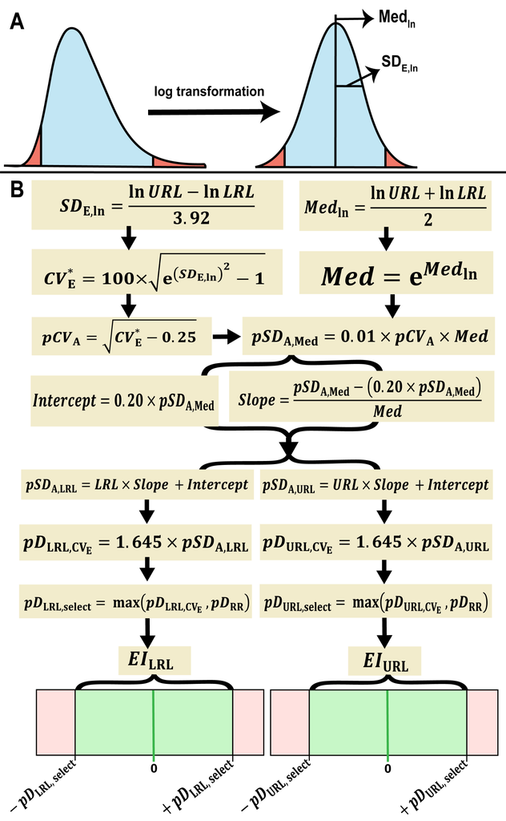

**Table 22.** Selecting the Permissible Difference for the Reference Limit (pD<sub>RL,select</sub>).

| Statistical parameters | LRL | URL |
| --- | --- | --- |
| \|D<sub>RL</sub>\| | 0.0 | 1.0 |
| pD<sub>RR</sub> | 0.3 | 0.3 |
| pD<sub>RL,CV<sub>E</sub></sub> | 5.2 | 13.9 |
| pD<sub>RL,select</sub> = max(pD<sub>RR</sub>; pD<sub>RL,CV<sub>E</sub></sub>) | 5.2 | 13.9 |

Footnote  
**RL**, reference limit. **RR**, Reporting range. **D<sub>RL</sub>**, absolute difference (modulus) between the reference limits. **pD<sub>RR</sub>**, permissible difference for the RL based on the RR. **pD<sub>RL,CV<sub>E</sub></sub>**, permissible difference for the RL based on Haeckel’s approach estimating the empirical coefficient of variation (CV<sub>E</sub>) from the reference interval. **pD<sub>RL,select</sub>**, permissible difference for the RL selected as the greater value between pD<sub>RR</sub> and pD<sub>RL,CV<sub>E</sub></sub>. **URL**, upper reference limit. **LRL**, lower reference limit.

**4.2.4. Interpretation of the second-level analysis**

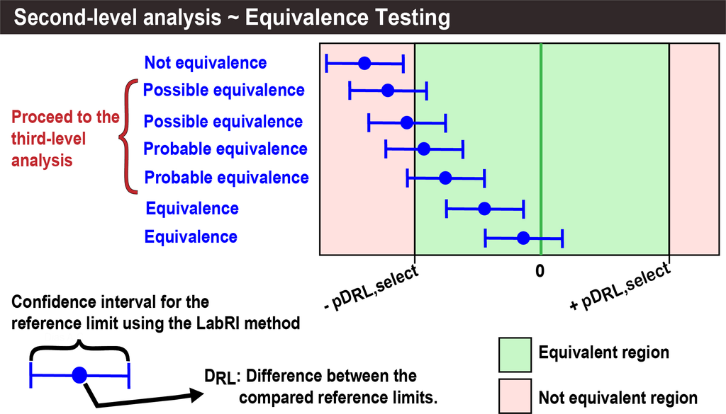

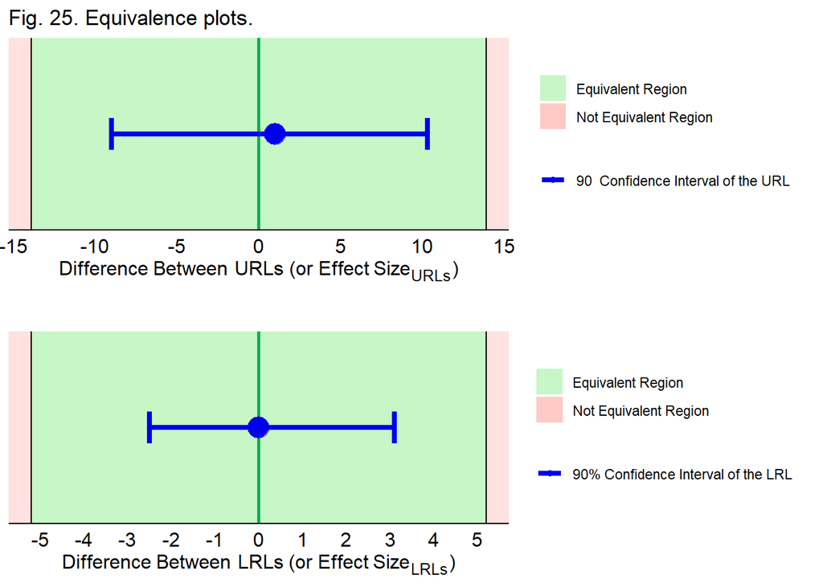

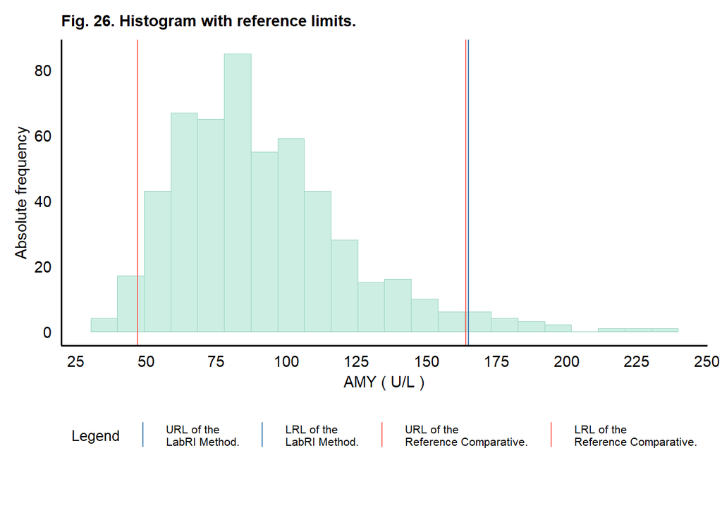

**4.2.5. Conclusion of the second-level analysis**

**Table 23.** Second-level analysis conclusion.

[output not shown]

### 4.3. Third-Level Analysis

**4.3.1.Interpretation of the third-level analysis**

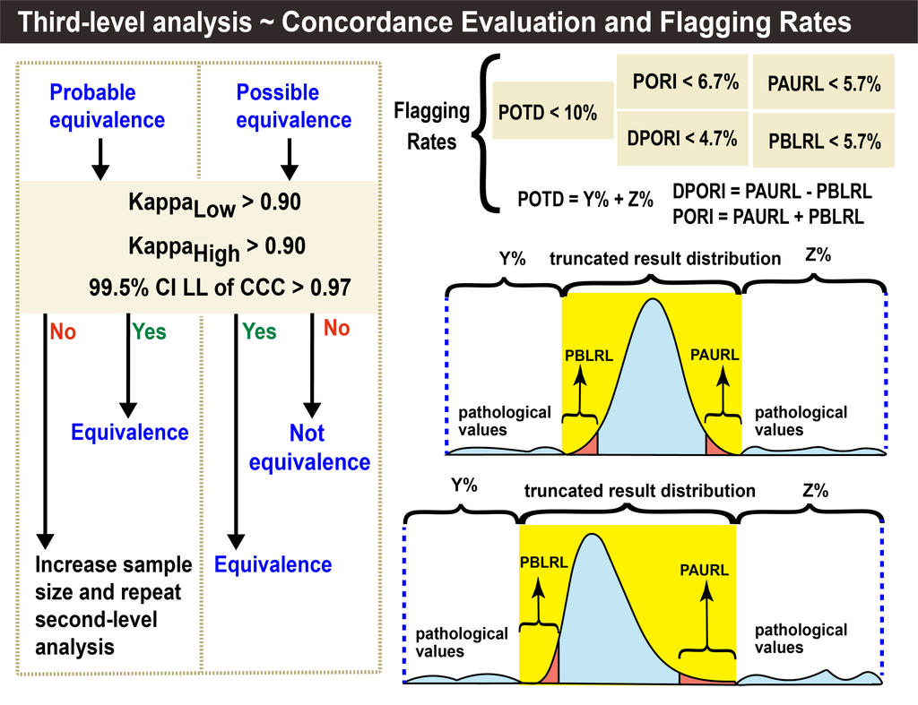

**4.3.2. Results obtained from the third-level analysis**

| Sample number | Patient's results | Comparative RI | LabRI Method RI |
| --- | --- | --- | --- |
| 1 | 161.97 | Normal | Normal |
| 2 | 79.99999999999997 | Normal | Normal |
| 3 | 97.95999999999998 | Normal | Normal |
| 4 | 66.00999999999999 | Normal | Normal |
| 5 | 58.95999999999998 | Normal | Normal |
| 6 | 72.98000000000003 | Normal | Normal |
| 7 | 103.96 | Normal | Normal |
| 8 | 80.98 | Normal | Normal |
| 9 | 71.98 | Normal | Normal |
| 10 | 78.95000000000003 | Normal | Normal |

[output cut: 521 more lines]

**4.3.3. Categorical agreement between LabRI and comparative reference intervals (Low/Normal/High)**

**Table 25.** 3×3 Contingency table comparing value interpretations based on RI.

|  | High | Low | Normal |
| --- | --- | --- | --- |
| High | 16 | 0 | 1 |
| Low | 0 | 16 | 0 |
| Normal | 0 | 0 | 498 |

Footnote  
Rows = Comparative Reference and Columns = LabRI method. RI, Reference Intervals **Concordance** 99.81% **Low**, values below the lower reference limit (LRL). **“Normal”**, The terms ‘healthy’ or ‘normal’ should not be used anymore because health and normality are relative conditions lacking a universal definition. There is often a gradual transition from ‘health’ to disease. In the present review, the term pathological values are used for values from diseased subjects, and non-pathological values for values from non-diseased subjects. However, for simplicity in this table, the term ‘normal’ is used to represent non-pathological values. **High**, values above the upper reference limit (URL).

**Table 26.** Fleiss kappa statistics for attribute agreement analysis between LabRI method and Comparative Reference in laboratory test Classifications.

| Statistical parameters | Low | ‘Normal’ | High | Global |
| --- | --- | --- | --- | --- |
| Fleiss’ kappa | 1 | 0.984 | 0.969 | 0.984 |
| p-value | <0.001 | <0.001 | <0.001 | <0.001 |
| Interpretation | Almost perfect agreement | Almost perfect agreement | Almost perfect agreement | Almost perfect agreement |

Footnote  
**The interpretation of the kappa values is as follows:** **< 0:** Agreement worse than chance. **≥ 0 to ≤ 0.40:** Poor agreement. **> 0.40 to ≤ 0.60:** Weak agreement. **> 0.60 to ≤ 0.80:** Moderate agreement. **> 0.80 to ≤ 0.90:** Strong agreement. **> 0.90 to ≤ 0.95:** Very strong agreement. **> 0.95 to ≤ 1.00:** Almost perfect agreement. **The cells are colored based on the kappa value:** ‘Very Strong’ to ‘Almost perfect’ agreement. Strong agreement. From ‘Agreement worse than chance’ to Moderate agreement. **References:** [[62]](https://doi.org/10.1002/0471445428), [[63]](https://doi.org/10.11613/BM.2012.031), [[64]](https://doi.org/10.1111/cea.14016), [[65]](https://doi.org/10.4067/S0034-98872021000100013) [[66]](https://doi.org/10.1080/00365513.2024.2437613)

**4.3.4. Agreement of standardized results (z/zlog) using LabRI vs comparative reference intervals**

[interactive chart not shown]

**Table 27.** Analysis of the Agreement of Standardized Results (zlog) based on Lin’s Concordance Correlation Coefficient (ρ<sub>c</sub>).

| Statistical parameters | Results |
| --- | --- |
| Sample size (N) | 533 |
| Subsample (n) | 533 |
| Sample size after removal of outliers (n<sub>New1</sub>) | 531 |
| Sample size after distribution truncation (n<sub>New2</sub>) | 531 |
| Lin’s Concordance Correlation Coefficient (ρ<sub>c</sub>) | 0.9999 |
| 99.5% Confidence interval of the ρ<sub>c</sub> | 0.9999 to 1 |
| Pearson correlation coefficient (ρ) - measure of precision | 1 |
| Bias correction factor (C<sub>b</sub>) - measure of trueness | 0.9999 |
| Interpretation | Almost perfect agreement |

Footnote  
**Interpretation based on the lower limit of the confidence interval for ρ<sub>c</sub> is as follows:** **< 0.90:** Poor agreement. **≥ 0.90 to ≤ 0.92:** Weak agreement. **≥ 0.92 to ≤ 0.95:** Moderate agreement. **≥ 0.95 to ≤ 0.97:** Strong agreement. **≥ 0.97 to ≤ 0.99:** Very strong agreement. **> 0.99:** Almost perfect agreement. **The cells are colored based on the lower limit of the confidence interval for ρ<sub>c</sub> is as follows:** ‘Very Strong’ to ‘Almost perfect’ agreement. Strong agreement. Poor to Moderate agreement. **References:** [[64]](https://doi.org/10.1111/cea.14016), [[65]](https://doi.org/10.4067/S0034-98872021000100013), [[67]](https://doi.org/10.1007/978-1-4614-0562-7), [[68]](https://doi.org/10.32614/CRAN.package.epiR)

[interactive chart not shown]

**Verification of flagging rates:**

- **POTD**, Percentage Outside Truncated Data. **DPORI**, Difference in Percentages Out of Reference Interval. **PORI**, Percentage Out of Reference Interval. **PAURL**, Percentage Above Upper Reference Limit. **PBLLR**, Percentage Below Lower Reference Limit. **%Y**, percentage of result below the truncated range. **%Z**, percentage of results above the truncated range.
- The expected flagging rates will be compared with their current rates derived from the calculations of the original indirect study. When the increase in flagging in any direction does not exceed the predefined quality targets, the RI under evaluation can be considered acceptable for use. The **goal** is to assess the flagging rates **to determine whether a change in the historical Reference Interval** will create higher flagging rates.
- Ideally, the percentages of results below the lower reference limit (**PBLRL**) and above the upper reference limit (**PAURL**) should be kept reasonably close to 2.5% to avoid significant changes in the sensitivity and specificity of the laboratory test. Based on the principle of the **minimum category used to define the allowed bias limits**, the flagging rates can reach a value of **5.7%** or lower for one of the reference limits, while the other limit would have a value of **1%** or lower.
- Verify if **POTD**, **DPORI**, **PORI**, **PAURL**, and **PBLLR** meet the pre-defined criteria based on studies of biological variation. Investigate the adopted partitioning criteria (e.g., age, sex, etc.) Verify the criteria for data exclusion and filtering. If it is identified that any of these parameters do not meet the pre-defined criteria, consider refining the criteria for data exclusion and filtering to achieve better standardization in future studies.

**Table 28.** Evaluation of the ‘Flagging Rates’ of Data from the ‘Truncation band’.

| Method | Sample size | POTD | PRWRI | PBLRL | PAURL | DPORI | PORI |
| --- | --- | --- | --- | --- | --- | --- | --- |
| RI<sub>LabRI</sub> | 531 | 0.38% | 93.97% | 3.01% | 3.01% | 0.00% | 6.03% |
| RI<sub>Comp</sub> | 531 | 0.38% | 93.79% | 3.01% | 3.20% | 0.19% | 6.21% |

Footnote  
**RI<sub>LabRI</sub>**, reference interval estimated by the LabRI method. **RI<sub>Comp</sub>**, comparative reference interval. **POTD**, Percentage Outside Truncated Data. **PRWRI**, Percentage Results Within the Reference Interval. **PBLRL**, Percentage Below Lower Reference Limit. **PAURL**, Percentage Above Upper Reference Limit. **DPORI**, Difference in Percentages Out of Reference Interval. **PORI**, Percentage Out of Reference Interval. When the total percentages of values outside the truncated range, PBLRL, PAURL, DPORI, and PORI,exceed 10%, 5.7%, 5.7%, 4.7%, and 6.7%, respectively, the table cell will have a red background. In these cases, it is recommended to review the exclusion criteria for reference individuals (if direct sampling is used) or the filtering criteria applied to the original database (if indirect sampling is used), or to review the partitioning used by sex or age group. **References:** [[8]](https://doi.org/10.1016/j.clinbiochem.2019.06.006), [[69]](https://www.ncbi.nlm.nih.gov/pmc/articles/PMC5111244/), [[70]](https://doi.org/10.1373/clinchem.2015.243055), [[71]](https://www.ncbi.nlm.nih.gov/pmc/articles/PMC4310060/), [[72]](https://doi.org/10.1093/clinchem/45.3.321), [[73]](https://doi.org/10.1515/CCLM.2004.123), [[74]](https://doi.org/10.1373/clinchem.2003.027953), [[75]](https://doi.org/10.4097/kjae.2016.69.6.555), [[76]](https://doi.org/10.1515/cclm-2016-0307), [77], [[78]](https://doi.org/10.3109/00365518809088757)

**4.3.3. Conclusion of the third-level analysis**

**Table 29.** Third-level analysis conclusion.

| Reference limits compared | Third-level analysis conclusion |
| --- | --- |
| URL<sub>LabRI</sub> vs URL<sub>Comp</sub> | The upper reference limits (URLs) were considered equivalent in the **second-level analysis**. Therefore, the **third-level analysis** will not be performed. |
| LRL<sub>LabRI</sub> vs LRL<sub>Comp</sub> | The lower reference limits (LRLs) were considered equivalent in the **second-level analysis**. Therefore, the **third-level analysis** will not be performed. |
| Flagging Rates - RI<sub>LabRI</sub> | The **Flagging Rates** associated with the reference interval estimated by the LabRI method meet the minimum targets based on biological variation studies. |
| Flagging Rates - RI<sub>Comp</sub> | The **Flagging Rates** associated with the reference interval defined as the Comparative Reference meet the minimum targets based on biological variation studies. |

## 5. Runtime

- This section of the code is designed to measure and log the runtime of the algorithm based on the sample size.

**Table 30.** Execution Time.

| Description | Time |
| --- | --- |
| Starting date and time | segunda-feira, 19 outubro, 2026, 15:14:59 |
| End date and time | segunda-feira, 19 outubro, 2026, 15:15:43 |
| Total runtime | 44.47 seconds |